# New Environmental Justice Mapping in PA

Richard Barad

2023-10-23

## Introduction

The Pennsylvania Department of Environmental Protection (DEP) adopted an interm new Environmental Justice Policy on September 16th, 2023. The new EJ Policy is currently available for public comments through November 30th 2023.

## What components are considered in the PennEvniroScreen score calculation?

The Penn Enviorscreen score is based on four different components:

- **Envioronmental Exposure**: Exposure to pollutants including air, water, and soil pollutants.
- **Envioronmental Effects**: Presence of infrastructure or sites which may cause pollution.
- **Sensitive Population**: Population health characteristics that result in increased vulnerability to environmental threats, such as having cancer, asthma, or a heart condition.
- **Socioeconomic Factors**: Factors pertaining to demographic and socio-economic status such as race, income levels, lack of education, and linguistic isolation (i.e: population that does not speak English).

Each component score is based on multiple indicators. In order for an indicator to be used in PennEnviroScreen the data for the indicator must be available at the census block group level. Additionally, the dataset must be available for the entire state of Pennsylvania and it must be updated at least once per year.

### Elements factored into each score:

**The Environmental Exposure Component** includes the following indicators:

- Ozone Levels
- Diesel Particulate Matter Level
- Toxic Air Emissions
- Toxic Water Emissions
- Pesticide Usage
- Traffic Density
- Compressor Stations
- Children’s Lead Risk

**The Environmental Effects Component** includes the following indicators:

- Number of fracking wells within 1km of census block
- Number of conventional oil and gas wells within 1km of census block
- Length or railroads within 1km of of census block
- Number of land remediation sites (i.e: superfund and brownfield sites) with 1km of census block
- Number of hazardous waste sites within 1km of census block
- Number of coal mining sites within 1km of census block
- Number of municipal waste sites within 1 km of census block
- Number of impaired water sites within 1 km of census block
- Number abandoned mines with 1 km of census block

**The Sensitive Population Component** includes the following indicators:

- Percent of population with Asthma
- Percent of population without health insurance
- Percent of population with cancer
- Percent of population that is disabled
- Percent of population with Coronary Heart Disease

**The Socioeconomic Component** includes the following indicators:

- Percent of Population with a High school degree
- Percent of population who do not speak English
- Percent of population living in poverty
- Percent of population which is housing burdened (i.e: struggles to pay rent)
- Percent of population which are people of color (i.e: not white)
- Percent of population that is unemployed
- Percent of population over 64
- Percent of population under 5

## How is PennEnviorScreen score calculated?

The process of calculating the PennEnviorScreen score based on the individual indicators follows a six step process outlined below and visualized in the graphic to the right.

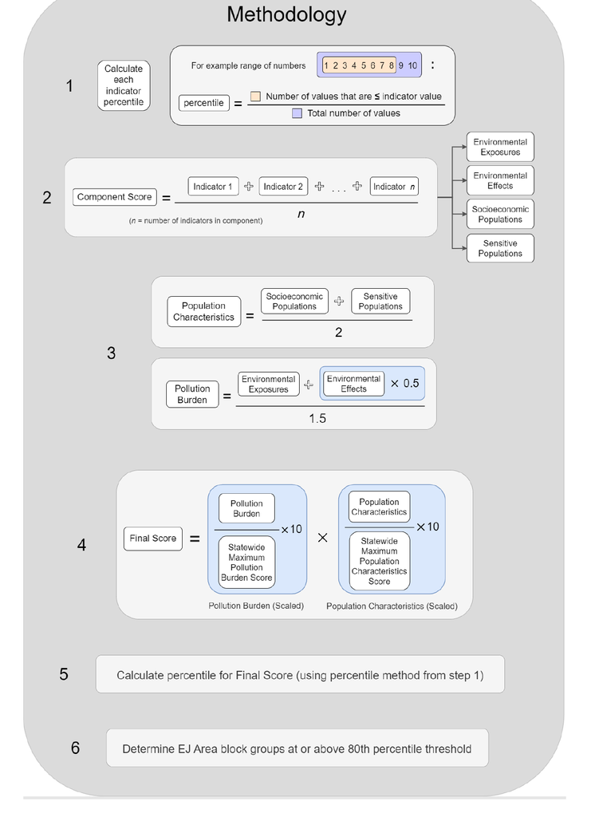

New Envioronmental Mapping PA Methodology

## What are the differences between the new and old EJ mapping protocols?

The old EJ Mapping protocols from 2015 only considered socioeconomic factors in the EJ area definition. Any census tract in which 20% of the population lived in poverty or 30% of the population identified as a minority was considered an EJ area. The new mapping protocol considers environmental exposure, environmental effects, and sensitive populations factor in addition to socioeconomic factors.

The map below provide a visual overview of EJ Areas using the 2015 and 2023 definitions. Notable areas where there has been a reduction in the number of census blocks identified as EJ areas incldue Monroe and Pike counties in Northeast PA, Chester county in southeast PA, and forest county. The counties where the number of census tracts classified as EJ areas has increased are primarily clustered in Southwest PA where large oil and gas mining operations are present.

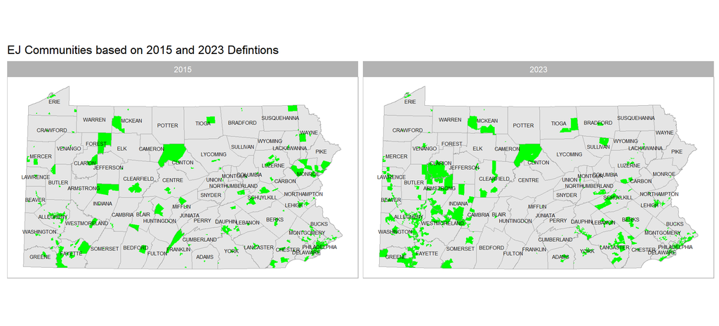

This map below shows areas identified as EJ Areas according to both the 2023 and 2015 definitions and areas as EJ communities only according to just the 2023 definition and just the 2015 definition. We can again observe that there are a significant number of areas which are no longer classified as EJ communities. This includes parts of Philadelphia. Lancaster county also includes many new EJ Areas according to the 2023 definition.

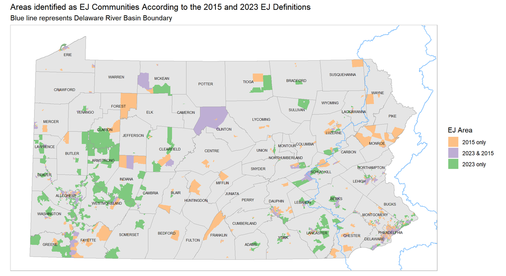

The table below shows the area classified as an Environmental Justice Area according to the 2015 and 2023 EJ Definitions. Overall, the area classified as an EJ Area has increased with the adoption of the new EJ Policy protocols.

| Year | Area classified as Enviormental Justice Area (square miles) |
| --- | --- |
| 2015 | 275.3251 |
| 2023 | 342.1588 |

## How was PennEviroScreen Methodology Developed?

The PennEnviroScreen Methodology was developed based on a review of platforms and EJ mapping protocols used by different federal state agencies. The federal government has a platform for EJ Screening, but its utility is limited because it does not present a single consolidated EJ Index.

DEP wanted to have a single index in order to allow policy makers and project implementers to be able to quickly determine where EJ Policies should apply - having a single index helped accomplish this goal. The Pennslyvania EnvrioScreen Methodology is based on the Methodology used in California in the [CalEnviorScreen 4.0](https://experience.arcgis.com/experience/11d2f52282a54ceebcac7428e6184203/page/CalEnviroScreen-4_0/)

## What are some of caveats to keep in mind when using the new EJ Mapping?

It is important to note that PennEnvioroScreen is based on multiple different environmental hazards. Project implementers who are interested in understanding a specific type of hazard (i.e: Water Pollution) might want to look at the information for the specific indicators related to water pollution instead of looking at the consolidated Environmental Justice index. The PennEnviorScreen Tool conveniently provides access to data on all indicators which are used as inputs to the PennEvniromentScreen index.

It is important to note that the PennEnviorScreen methodology relies on percentiles. Each census block is compared to the rest of the census blocks in the state. This means that some blocks will always be assigned high percentile values, even if they meet regulatory standards.

Additionally, because of the 80 percentile rule which is used to identify EJ Areas, 20% of census tracts will always be identified as EJ Area even if the presence of environmental hazards declines statewide.

## What does the map of EJ communities in the Delware Basin look like?

The map below shows census block groups in the Delaware river basin identified as EJ communities according to the 2015 environmental justice defintiion and the new 2023 enviormental justice community definitions.

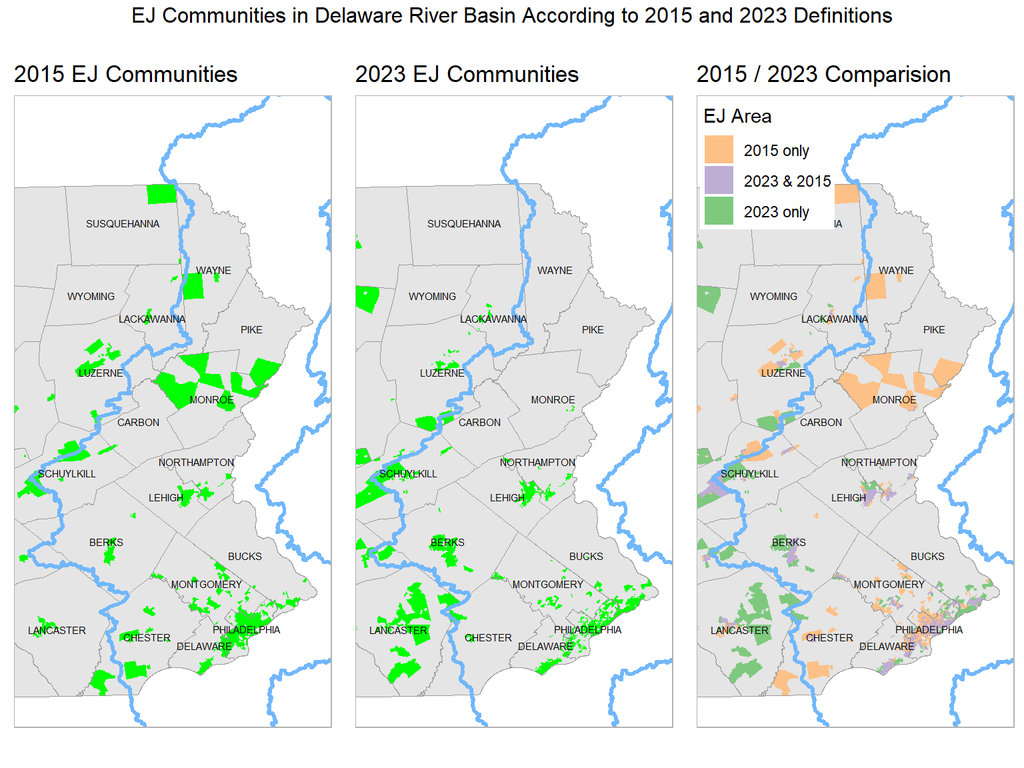